# Lab Part 1 - LA

Laurel Abowd

12/4/2020

## Multiple linear regression

# Visualization with ggpairs plot

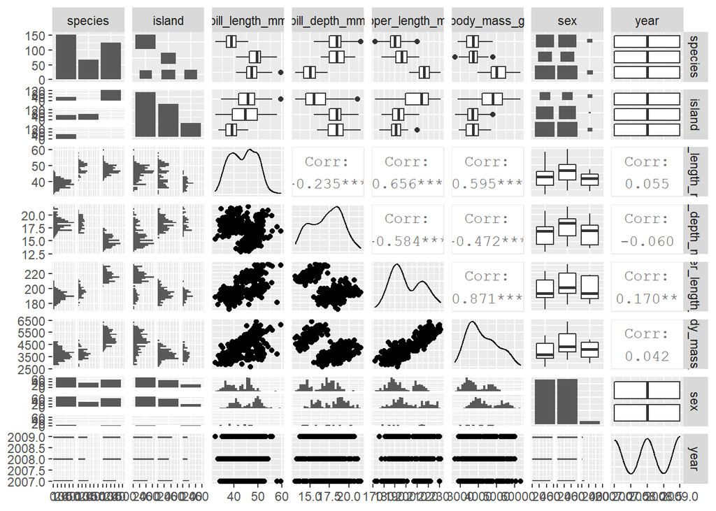

```r
penguins %>%
  ggpairs()
```

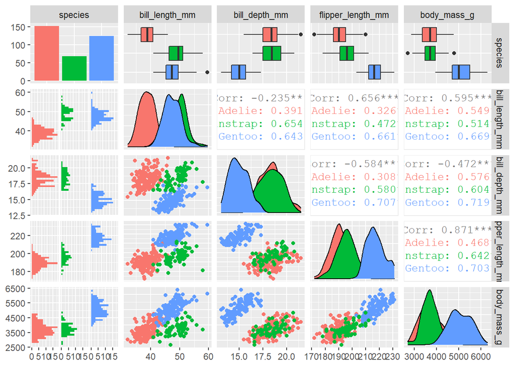

```r
penguins %>%
  select(species, bill_length_mm:body_mass_g) %>%
  ggpairs(aes(color = species))
```

So there are moderate positive correlations that exist (e.g. the 0.719 between body mass & bill depth for gentoos), but nothing *really* high - collinearity is not a concern here (though you could explore it with the `car::vif()` function.

## Build a few different models.

Here, we are going to compare different versions of a regression model with penguin mass as the dependent variable in each. **DISCLAIMER:** If we were doing this in the wild, we’d need to do *a lot* of background research to understand conceptually which variables should be included and why. As we are (probably) not penguin experts, we will pretend we’ve already done that extensive research and exploration to justify variable selection.

Create the 4 models in your code as follows:

```r
lm1 <- lm(body_mass_g ~ flipper_length_mm + species, data = penguins)

lm2 <- lm(body_mass_g ~ flipper_length_mm + species + sex, data = penguins)

lm3 <- lm(body_mass_g ~ flipper_length_mm + species + sex + bill_length_mm, data = penguins)

lm4 <- lm(body_mass_g ~ flipper_length_mm + species + sex + bill_length_mm + island, data = penguins)
```

Explore the outputs of the different model variations. How does the coefficient of determination (adjusted R<sup>2</sup>) change? How do the coefficient values change?

We should also look at the diagnostics for each. Do you have any second thoughts about the model validity when you explore diagnostic plots for normality of residuals, homoscedasticity and potential outliers?

## Compare the model AIC values

In lecture we learned about the Akaike Information Criterion to compare the “quality” of models, as a measure of balance between model fit and complexity (since there is a penalty for added variables). Use the `AIC` function to find the AIC value for each model:

```r
AIC(lm1) # 5031.52
```

```
## [1] 5031.523
```

```r
AIC(lm2) # 4740.77
```

```
## [1] 4740.774
```

```r
AIC(lm3) # 4733.57 (lowest of these 4 - best AIC)
```

```
## [1] 4733.574
```

```r
AIC(lm4) # 4736.98 (added island, AIC goes UP)
```

```
## [1] 4736.979
```

Based on these 4 models only, what model does the Akaike Information Criterion indicate is the best balance between fit & complexity?

Does that mean we should choose to pick that model based on that alone? No! It is on more piece of information to consider. Context, critical thinking, conceptual understanding of relationships between variables all need to be the major drivers in variable selection.

## Returning results of multiple models

```
"All models are wrong, but some are useful." - George Box
```

All models are wrong, and sometimes it’s hard to know which one is the *best* – so sometimes, it makes sense to show the results of multiple model permutations and let the audience compare them on their own.

The `stargazer` package, which we used to make a table of regression results last week, allows you to quickly show results of multiple regression models side-by-side!

```r
stargazer(lm1, lm2, lm3, lm4, type = "html")
```

|  | *Dependent variable:* |  |  |  |
| --- | --- | --- | --- | --- |
|  | body_mass_g |  |  |  |
|  | (1) | (2) | (3) | (4) |
| flipper_length_mm | 40.705*** | 20.025*** | 17.847*** | 18.138*** |
|  | (3.071) | (2.846) | (2.902) | (2.933) |
| speciesChinstrap | -206.510*** | -87.634* | -291.711*** | -293.045*** |
|  | (57.731) | (46.347) | (81.502) | (89.455) |
| speciesGentoo | 266.810*** | 836.260*** | 707.028*** | 676.103*** |
|  | (95.264) | (85.185) | (94.359) | (104.019) |
| sexmale |  | 530.381*** | 465.395*** | 463.640*** |
|  |  | (37.810) | (43.081) | (43.292) |
| bill_length_mm |  |  | 21.633*** | 21.528*** |
|  |  |  | (7.148) | (7.183) |
| islandDream |  |  |  | -23.244 |
|  |  |  |  | (59.413) |
| islandTorgersen |  |  |  | -47.212 |
|  |  |  |  | (61.909) |
| Constant | -4,031.477*** | -365.817 | -759.064 | -785.564 |
|  | (584.151) | (532.050) | (541.377) | (545.027) |
| Observations | 342 | 333 | 333 | 333 |
| R<sup>2</sup> | 0.783 | 0.867 | 0.871 | 0.871 |
| Adjusted R<sup>2</sup> | 0.781 | 0.865 | 0.869 | 0.868 |
| Residual Std. Error | 375.535 (df = 338) | 295.565 (df = 328) | 291.955 (df = 327) | 292.590 (df = 325) |
| F Statistic | 405.693*** (df = 3; 338) | 534.024*** (df = 4; 328) | 439.680*** (df = 5; 327) | 312.778*** (df = 7; 325) |
| *Note:* | p<0.1; p<0.05; p<0.01 |  |  |  |

## Omitted variable bias in action - Simpson’s paradox

In lecture, we learned about omitted variable bias. One special case is when the trend is completely reversed due to an erroneously omitted variable. Let’s explore that in penguins!

First, let’s make a graph of flipper length versus bill depth, ignoring species:

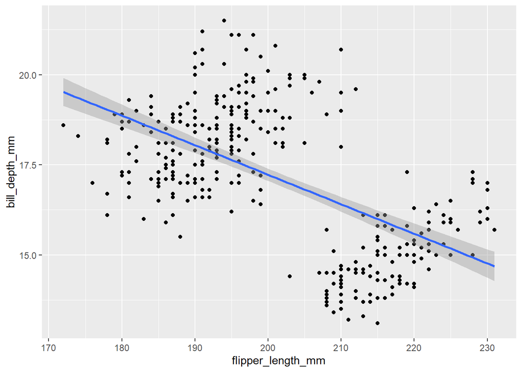

```r
ggplot(data = penguins, aes(x = flipper_length_mm, y = bill_depth_mm)) +
  geom_point() +
  geom_smooth(method = "lm")
```

We can see that the resulting trend, if we ignore other variables, is *negative*. What happens when we *include* species as a variable?

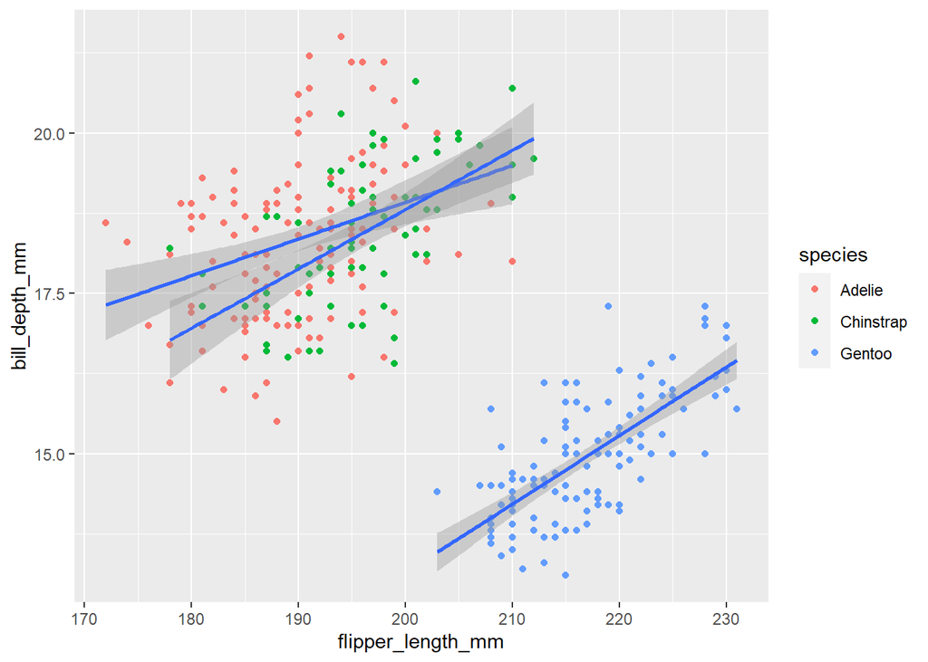

```r
ggplot(data = penguins, aes(x = flipper_length_mm, y = bill_depth_mm,
                            group = species)) +
  geom_point(aes(color = species)) +
  geom_smooth(method = "lm")
```

Now we can see the takeaway trend within each group is the opposite: there is a positive trend between flipper length and bill depth!

## END PART 1